# Clustering NBA Teams

## Partitioning Methods: K-Means Clustering.

As an alternative to hierarchical clustering, there are **partitioning methods**. The most popular of those is called **$K$-means**. $K$-means is much better for **bigger datasets**, where computational demands become an issue (not precisely our case, but still good to know).

A great video on $K$-means clustering (especially first 9 minutes):

https://www.youtube.com/watch?v=RD0nNK51Fp8

In the end,

- Algorithm yields $K$ **centroids** - average vectors, which serve as **centers** of their respective clusters.
- Each object in the data is assigned to the cluster with the closest centroid.

Function $kmeans()$ in $R$ allows us to run the $K$-means clustering:

```r
kmeans(all_stats, centers=5, nstart=50,iter.max = 100)
```

```
## K-means clustering with 5 clusters of sizes 11, 4, 4, 9, 2
##
## Cluster means:
##         FGA.x       FG%.x      3PA.x       3P%.x      ORB.x      TRB.x
## 1  0.13389147 -0.02211998  0.2153996  0.36417411 -0.1587296 -0.4514285
## 2 -1.83944803 -0.12795263 -0.1247164 -0.34507884 -1.1444861 -1.3416349
## 3  1.12669524 -0.71003223  0.2452629 -1.43282736  1.0539186  1.3126691
## 4  0.17069381 -0.14543250 -0.3558463  0.06334781  0.4731768  0.5137063
## 5 -0.07901961  2.45207585  0.1755174  1.26778966 -1.0751474  0.2291099
##         AST.x        BLK      TOV.x          PF       FGA.y       FG%.y
## 1  0.04263713 -0.7640036 -0.3661278 -0.63716321 -0.09266108  0.92512634
## 2 -0.58062784  0.3592705 -0.3778467  0.77122688 -1.47757611  0.05529181
## 3  0.22549959 -0.1346178  1.5611607  1.18626906  1.24217469 -0.26836755
## 4 -0.49705782  0.3765469 -0.3153114 -0.02214864 -0.15476117 -0.84600961
## 5  2.71251246  2.0582535  1.0659763 -0.31092533  1.67686404 -0.85500015
##        3PA.y      3P%.y        ORB.y       TRB.y      AST.y        TOV.y
## 1  0.4516361  0.6604812 -0.214270084  0.08592335  0.8771351  0.184103465
## 2 -1.0871765  1.0335563 -0.757880589 -0.61687142 -1.0775033  0.205092954
## 3 -0.2215182 -0.7333690  0.668625186  1.11590138 -0.4736476 -0.524703523
## 4 -0.1556889 -0.9085838  0.005367396 -0.27616838 -0.5163266 -0.001999994
## 5  0.8339907 -0.1443939  1.332842988 -0.22788063  0.6015285 -0.364347950
##
## Clustering vector:
##          Atlanta Hawks         Boston Celtics          Brooklyn Nets
##                      1                      4                      3
##      Charlotte Hornets          Chicago Bulls    Cleveland Cavaliers
##                      4                      1                      1
##       Dallas Mavericks         Denver Nuggets        Detroit Pistons
##                      1                      1                      1
##  Golden State Warriors        Houston Rockets         Indiana Pacers
##                      5                      1                      1
##   Los Angeles Clippers     Los Angeles Lakers      Memphis Grizzlies
##                      4                      3                      2
##             Miami Heat        Milwaukee Bucks Minnesota Timberwolves
##                      2                      2                      1
##   New Orleans Pelicans        New York Knicks  Oklahoma City Thunder
##                      5                      4                      4
##          Orlando Magic     Philadelphia 76ers           Phoenix Suns
##                      1                      3                      3
## Portland Trail Blazers       Sacramento Kings      San Antonio Spurs
##                      4                      1                      4
##        Toronto Raptors              Utah Jazz     Washington Wizards
##                      4                      2                      4
##
## Within cluster sum of squares by cluster:
## [1] 130.15971  22.43444  33.18313  77.12623  13.81139
##  (between_SS / total_SS =  47.0 %)
##
## Available components:
##
## [1] "cluster"      "centers"      "totss"        "withinss"
## [5] "tot.withinss" "betweenss"    "size"         "iter"
## [9] "ifault"
```

Natural questions - **how do we select $K$**? One approach is as follows:

- Run $K$-means for a grid of $K$ values (from $1$ up to $n-1$).
- Record the **within-cluster sum of squares (WSS)** metric for each $K$ value, which shows how **homogeneous** (hence good) your clusters are
- Provide the “elbow plot” of those WSS values as $K$ increases, look for the “elbow point” - the point that’s most removed from the straight line connecting first and last WSS values - which will correspond to an “optimal”" $K$ value.

```r
k.max <- 29
wss <- sapply(1:k.max,
              function(k){kmeans(all_stats, k, nstart=50,iter.max = 100)$tot.withinss})
wss
```

```
##  [1] 522.000000 435.561696 373.943671 319.765168 276.714902 247.321835
##  [7] 221.284706 199.865235 179.620996 160.005531 145.700966 131.821546
## [13] 120.340610 110.139097 100.092782  91.284257  81.341209  73.657254
## [19]  65.947188  58.439662  51.239390  44.629691  36.527854  29.719352
## [25]  23.610531  17.687266  12.541165   7.412245   2.970482
```

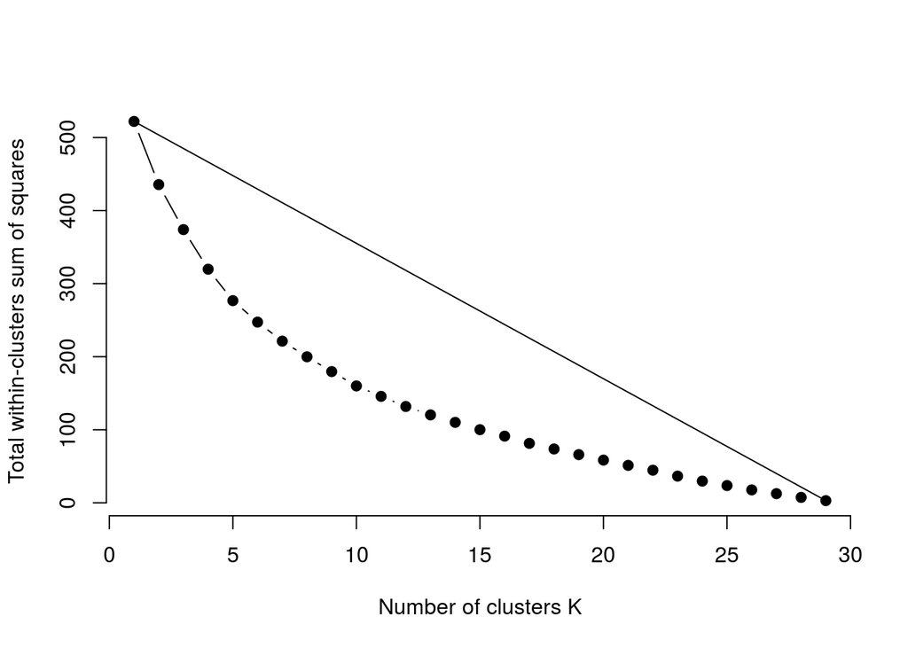

```r
plot(1:k.max, wss,
     type="b", pch = 19, frame = FALSE,
     xlab="Number of clusters K",
     ylab="Total within-clusters sum of squares")

lines(c(1,k.max),c(wss[1],wss[k.max]))
```

```r
k.opt <- 7
kmeans.res <- kmeans(all_stats, k.opt, nstart=50, iter.max = 100)
kmeans.res$cluster
```

```
##          Atlanta Hawks         Boston Celtics          Brooklyn Nets
##                      7                      5                      4
##      Charlotte Hornets          Chicago Bulls    Cleveland Cavaliers
##                      1                      4                      7
##       Dallas Mavericks         Denver Nuggets        Detroit Pistons
##                      2                      1                      7
##  Golden State Warriors        Houston Rockets         Indiana Pacers
##                      6                      1                      7
##   Los Angeles Clippers     Los Angeles Lakers      Memphis Grizzlies
##                      5                      3                      2
##             Miami Heat        Milwaukee Bucks Minnesota Timberwolves
##                      2                      2                      7
##   New Orleans Pelicans        New York Knicks  Oklahoma City Thunder
##                      6                      5                      1
##          Orlando Magic     Philadelphia 76ers           Phoenix Suns
##                      4                      3                      4
## Portland Trail Blazers       Sacramento Kings      San Antonio Spurs
##                      5                      7                      5
##        Toronto Raptors              Utah Jazz     Washington Wizards
##                      5                      2                      5
```

Let’s list the resulting clusters by team names:

```r
for (k in 1:k.opt){
  print(k)
  print(rownames(all_stats)[which(kmeans.res$cluster==k)])
}
```

```
## [1] 1
## [1] "Charlotte Hornets"     "Denver Nuggets"        "Houston Rockets"
## [4] "Oklahoma City Thunder"
## [1] 2
## [1] "Dallas Mavericks"  "Memphis Grizzlies" "Miami Heat"
## [4] "Milwaukee Bucks"   "Utah Jazz"
## [1] 3
## [1] "Los Angeles Lakers" "Philadelphia 76ers"
## [1] 4
## [1] "Brooklyn Nets" "Chicago Bulls" "Orlando Magic" "Phoenix Suns"
## [1] 5
## [1] "Boston Celtics"         "Los Angeles Clippers"
## [3] "New York Knicks"        "Portland Trail Blazers"
## [5] "San Antonio Spurs"      "Toronto Raptors"
## [7] "Washington Wizards"
## [1] 6
## [1] "Golden State Warriors" "New Orleans Pelicans"
## [1] 7
## [1] "Atlanta Hawks"          "Cleveland Cavaliers"
## [3] "Detroit Pistons"        "Indiana Pacers"
## [5] "Minnesota Timberwolves" "Sacramento Kings"
```

```r
# Specify which cluster you're interested in.
k.int <- 4
teams.int <- rownames(all_stats)[which(kmeans.res$cluster==k.int)]
print(teams.int)
```

```
## [1] "Brooklyn Nets" "Chicago Bulls" "Orlando Magic" "Phoenix Suns"
```

```r
our.table <- data.frame()
for (j in colnames(all_stats)){
  our.table <- rbind(our.table, ranking.calc(j,teams.int))
}
rownames(our.table) <- colnames(all_stats)
colnames(our.table) <- teams.int

#grid.newpage()
#grid.table(our.table)

print(our.table)
```

```
##       Brooklyn Nets Chicago Bulls Orlando Magic Phoenix Suns
## FGA.x             4             2             8            6
## FG%.x            30            29            16           27
## 3PA.x             2             8            13           20
## 3P%.x            28            16            23           29
## ORB.x            10            19            22            3
## TRB.x             4            10            21            6
## AST.x            18             5             8           26
## BLK              26            28            14           21
## TOV.x             9            25            11            5
## PF                9            23            19            6
## FGA.y             4             9             6            5
## FG%.y            15             9             4           11
## 3PA.y            29             5            25           20
## 3P%.y            18            10             3           14
## ORB.y            15            29             4            5
## TRB.y             2             4             1            6
## AST.y            23             3             4           20
## TOV.y            29            30            23           28
```